# Homework 3

Sevil Çalışkan

13.05.2018

```r
library(faraway)
library(magrittr)
library(tidyverse)
library(knitr)
library(kableExtra)
library(lattice)
```

```r
library(ggplot2)
library(plyr)
d <- data(pima)
#?faraway::pima
knitr::opts_chunk$set(echo = TRUE, cache=TRUE)
```

## Question 1

In Question 1, it is give that a grocer can measure the exact weight of anything weighing between 1 and 40 grams (integers only) in his store with his scale and four scale weights. It is asked what can those four scale weights be. The hint is whether the problem can be modelled as regression. Thinking over the hint, I have realised that 4 scale weights can be either used for the weighting purpose or not. For the weighting purpose, it can be used either side of the scale, which leaves us with 3 choices: ${-1,0,1} $. Add to the weigth side, substract from weight side or do nothing with $3^4 = 81$ cases. We want to weigth the values from 1 to 40, this leaves us with 81 responses adding negative and zero responses. Then, we can set a linear regression model with cases and responses and the coefficients would be the scale weights. Solution can be seen below.

```r
x1 = x2 = x3 = x4 =seq(-1,1,len = 3)
y = seq(-40,40,len = 81)
d <- expand.grid(x1,x2,x3,x4)
d <- cbind(d,y)

lm(y ~ Var1 + Var2 + Var3 + Var4 , d)
```

```
##
## Call:
## lm(formula = y ~ Var1 + Var2 + Var3 + Var4, data = d)
##
## Coefficients:
## (Intercept)         Var1         Var2         Var3         Var4
##  -1.332e-15    1.000e+00    3.000e+00    9.000e+00    2.700e+01
```

After fitting the model, we see that the four scale weights are 1, 3, 9 and 27 grams.

In part b, we shall perform the same analysis above with 6 scale weights and to weight from 1 to 364 grams.

```r
x1 = x2 = x3 = x4 = x5 = x6 = seq(-1,1,len = 3)
y = seq(-364,364,len = 364*2+1)
d <- expand.grid(x1,x2,x3,x4,x5,x6)
d <- cbind(d,y)

lm(y ~ Var1 + Var2 + Var3 + Var4 + Var5 + Var6 , d)
```

```
##
## Call:
## lm(formula = y ~ Var1 + Var2 + Var3 + Var4 + Var5 + Var6, data = d)
##
## Coefficients:
## (Intercept)         Var1         Var2         Var3         Var4
##   1.053e-14    1.000e+00    3.000e+00    9.000e+00    2.700e+01
##        Var5         Var6
##   8.100e+01    2.430e+02
```

After fitting the model, we see that the six scale weights are 1, 3, 9, 27, 81 and 243 grams and it can be seen that they follow the powers of 3.

## Question 2

Pima data is given by the faraway package and the histograms of insulin regarding diabetes test is drawn as below:

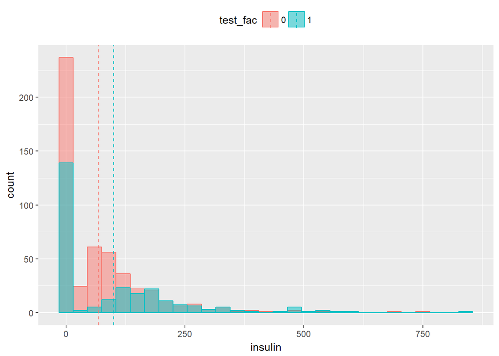

```r
hist_data <-
  pima %>%
  mutate(test_fac = factor(test)) %>%
  subset(., select = c(insulin,test_fac))

mu <- hist_data %>%
  ddply("test_fac", summarise, grp.mean=mean(insulin))

hist_data %>%
  ggplot(aes(x = insulin,fill =test_fac,color = test_fac)) +
  geom_histogram(binwidth=30, position="identity", alpha = 0.5)+
  geom_vline(data=mu, aes(xintercept=grp.mean, color=test_fac),
             linetype="dashed")+
  theme(legend.position="top")
```

We see that for both groups, whether the patient shows signs of diabetes, zero insulin level seems to be most counted level, while it is not really likely for a person to have a zero level of insulin since it is one of the vital hormones. As as result, zero level probably reflects the unknown/missing values so we should remove them.

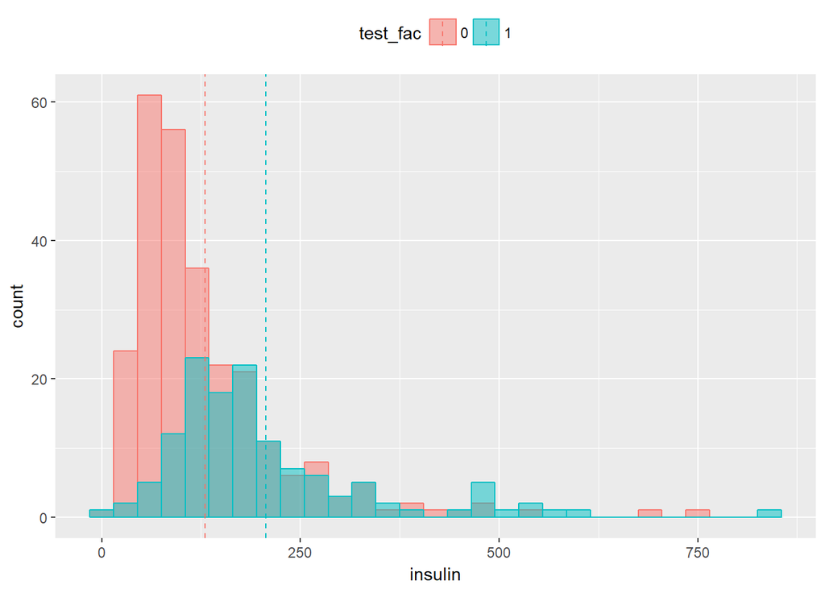

```r
hist_data$insulin[hist_data$insulin == 0] <- NA

 mu <- hist_data %>%
  ddply("test_fac", summarise, grp.mean=mean(insulin, na.rm = TRUE))

hist_data %>%
  ggplot(aes(x = insulin,fill =test_fac,color = test_fac)) +
  geom_histogram(binwidth=30, position="identity", alpha = 0.5)+
  geom_vline(data=mu, aes(xintercept=grp.mean, color=test_fac),
             linetype="dashed")+
  theme(legend.position="top")
```

Above true histogram of insuline levels for two groups can be seen. From the figure, we can say that patients who do not show any sign of diabetes have lower levels of insuline while the ones shows the sign of the diabetes have higher levels.

```r
data <- pima
data$glucose[data$glucose == 0] <- NA
data$diastolic[data$diastolic == 0] <- NA
data$triceps[data$triceps == 0] <- NA
data$insulin[data$insulin == 0] <- NA
data$bmi[data$bmi == 0] <- NA
data$age[data$age == 0] <- NA
data$test <- factor(data$test)
```

We should replace some zero values with NA since they are not likely to be observed and indicate missing values. Those values are glucosei diastolic, triceps, insuline and bmi since those cannot be zero for a person alive. Also, study conducted on adult people so age also cannot be zero.

```r
lmod <- glm(test ~ ., family=binomial, data)

summary(lmod)
```

```
##
## Call:
## glm(formula = test ~ ., family = binomial, data = data)
##
## Deviance Residuals:
##     Min       1Q   Median       3Q      Max
## -2.7823  -0.6603  -0.3642   0.6409   2.5612
##
## Coefficients:
##               Estimate Std. Error z value Pr(>|z|)
## (Intercept) -1.004e+01  1.218e+00  -8.246  < 2e-16 ***
## pregnant     8.216e-02  5.543e-02   1.482  0.13825
## glucose      3.827e-02  5.768e-03   6.635 3.24e-11 ***
## diastolic   -1.420e-03  1.183e-02  -0.120  0.90446
## triceps      1.122e-02  1.708e-02   0.657  0.51128
## insulin     -8.253e-04  1.306e-03  -0.632  0.52757
## bmi          7.054e-02  2.734e-02   2.580  0.00989 **
## diabetes     1.141e+00  4.274e-01   2.669  0.00760 **
## age          3.395e-02  1.838e-02   1.847  0.06474 .
## ---
## Signif. codes:  0 '***' 0.001 '**' 0.01 '*' 0.05 '.' 0.1 ' ' 1
##
## (Dispersion parameter for binomial family taken to be 1)
##
##     Null deviance: 498.10  on 391  degrees of freedom
## Residual deviance: 344.02  on 383  degrees of freedom
##   (376 observations deleted due to missingness)
## AIC: 362.02
##
## Number of Fisher Scoring iterations: 5
```

When we fit a model after replacing the values, we see that 392 observations were used for the model and it is less than 768 observations of total. It is less than total observations because rows or observations with NA values are not used while fitting the model.

```r
lmods <- glm(test ~ pregnant + glucose + diastolic + bmi + diabetes + age, family=binomial, data)
summary(lmods)
```

```
##
## Call:
## glm(formula = test ~ pregnant + glucose + diastolic + bmi + diabetes +
##     age, family = binomial, data = data)
##
## Deviance Residuals:
##     Min       1Q   Median       3Q      Max
## -2.8062  -0.7229  -0.4049   0.7173   2.3959
##
## Coefficients:
##              Estimate Std. Error z value Pr(>|z|)
## (Intercept) -8.962146   0.820892 -10.918  < 2e-16 ***
## pregnant     0.117863   0.033418   3.527  0.00042 ***
## glucose      0.035194   0.003605   9.763  < 2e-16 ***
## diastolic   -0.008916   0.008618  -1.035  0.30084
## bmi          0.090926   0.015740   5.777 7.61e-09 ***
## diabetes     0.960515   0.306415   3.135  0.00172 **
## age          0.016944   0.009834   1.723  0.08489 .
## ---
## Signif. codes:  0 '***' 0.001 '**' 0.01 '*' 0.05 '.' 0.1 ' ' 1
##
## (Dispersion parameter for binomial family taken to be 1)
##
##     Null deviance: 931.94  on 723  degrees of freedom
## Residual deviance: 672.86  on 717  degrees of freedom
##   (44 observations deleted due to missingness)
## AIC: 686.86
##
## Number of Fisher Scoring iterations: 5
```

In order to test the models, we cannot use deviance or chisquare test since number of samples are different. However, we can test whether models predict well or not by setting the prediction treshold to 0.5 (i.e if predicted success probability is greater than 0.5, we accept that model predicts success). By changing this treshold, we can observe how well model performs at different treshold and draw an ROC curve. Area under the ROC curve reflects how well the model performs.

```r
data_mod1 <- data
data_mod1 <- na.omit(data_mod1)
data_mod1 <- mutate(data_mod1, predprob=predict(lmod, type="response"), predout=ifelse(predprob < 0.5, "no", "yes"))
pre1 <- xtabs( ~ test + predout, data_mod1)
(pre1[1,1]+pre1[2,2])/sum(pre1)
```

```
## [1] 0.7831633
```

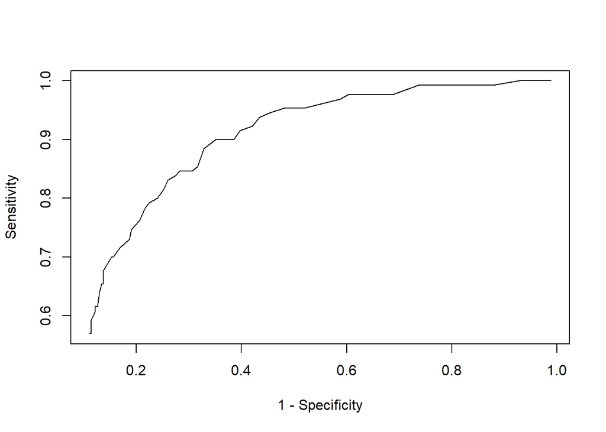

```r
thresh <- seq(0.01,0.5,0.01)
Sensitivity <- numeric(length(thresh))
Specificity <- numeric(length(thresh))

for(j in seq(along=thresh)){
  pp <- ifelse(data_mod1$predprob < thresh[j],"no","yes")
  xx <- xtabs( ~ test + pp, data_mod1)
  Specificity[j] <- xx[1,1]/(xx[1,1]+xx[1,2])
  Sensitivity[j] <- xx[2,2]/(xx[2,1]+xx[2,2])
}

plot(1-Specificity,Sensitivity,type="l")
```

```r
# #data_mod2 <- subset(data, select = c(pregnant , glucose , diastolic , bmi , diabetes , age,test))
# data_mod2 <- na.omit(subset(data, select = c(pregnant , glucose , diastolic , bmi , diabetes , age,test)))
# data_mod2 <- mutate(data_mod2, predprob=predict(lmods, type="response"),predout=ifelse(predprob < 0.5, "no", "yes"))
# pre2 <- xtabs( ~ test + predout, data_mod2)
# (pre2[1,1]+pre2[2,2])/sum(pre2)
#
#
# for(j in seq(along=thresh)){
#   pp <- ifelse(data_mod2$predprob < thresh[j],"no","yes")
#   xx <- xtabs( ~ test + pp, data_mod2)
#   Specificity[j] <- xx[1,1]/(xx[1,1]+xx[1,2])
#   Sensitivity[j] <- xx[2,2]/(xx[2,1]+xx[2,2])
# }
#
# plot(1-Specificity,Sensitivity,type="l")
```

```r
c(AIC(lmod), AIC(lmods))
```

```
## [1] 362.0212 686.8611
```

```r
data <- na.omit(data)
lmods <- glm(test ~ pregnant + glucose + diastolic + bmi + diabetes + age, family=binomial, data)
summary(lmods)
```

```
##
## Call:
## glm(formula = test ~ pregnant + glucose + diastolic + bmi + diabetes +
##     age, family = binomial, data = data)
##
## Deviance Residuals:
##     Min       1Q   Median       3Q      Max
## -2.8832  -0.6537  -0.3704   0.6502   2.5763
##
## Coefficients:
##               Estimate Std. Error z value Pr(>|z|)
## (Intercept) -9.9604796  1.1818764  -8.428  < 2e-16 ***
## pregnant     0.0840497  0.0550728   1.526 0.126971
## glucose      0.0364863  0.0049973   7.301 2.85e-13 ***
## diastolic   -0.0008002  0.0118034  -0.068 0.945949
## bmi          0.0785728  0.0215674   3.643 0.000269 ***
## diabetes     1.1492368  0.4250340   2.704 0.006854 **
## age          0.0346079  0.0181919   1.902 0.057121 .
## ---
## Signif. codes:  0 '***' 0.001 '**' 0.01 '*' 0.05 '.' 0.1 ' ' 1
##
## (Dispersion parameter for binomial family taken to be 1)
##
##     Null deviance: 498.10  on 391  degrees of freedom
## Residual deviance: 344.88  on 385  degrees of freedom
## AIC: 358.88
##
## Number of Fisher Scoring iterations: 5
```

It makes more sense to remover all the observations with missing data since those missing values may include information that may change the fit or model chose. Models should be tested with equal number of data whose all variables are known.

The odds of testing positive for diabetes for a woman increase by $e^{_{bmi}*x_{bmi}} $ with 1 unit increase in BMI assuming that all other factors are held constant. As a result, the difference in the odds of testing positive for diabetes for a woman with a BMI at the first quartile compared with a woman at the third quartile is given as below:

```r
q <- quantile(data$bmi)

c(exp(coef(summary(lmods))["bmi",1]*q[[1]]),exp(coef(summary(lmods))["bmi",1]*q[[2]]))
```

```
## [1] 4.178805 9.313530
```

```r
c(exp(coef(summary(lmods))["bmi",1]*q[[3]]),exp(coef(summary(lmods))["bmi",1]*q[[4]]))
```

```
## [1] 13.58027 18.44977
```

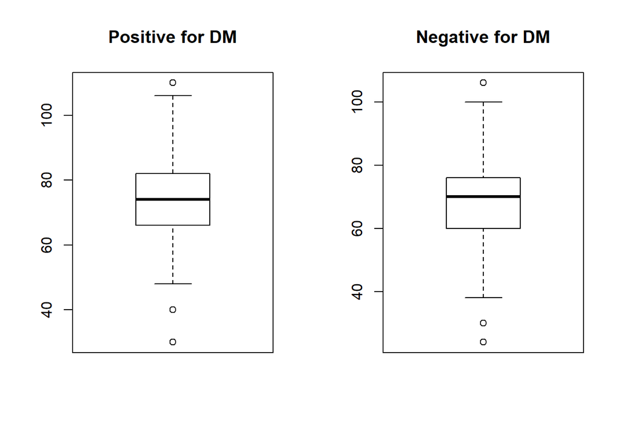

```r
# Straight from the data
pos_dm <- subset(data$diastolic, data$test == 1)
neg_dm <- subset(data$diastolic, data$test == 0)

par(mfrow=c(1,2))
boxplot(pos_dm, main="Positive for DM")
boxplot(neg_dm, main="Negative for DM")
```

```r
t.test(pos_dm,neg_dm)
```

```
##
##  Welch Two Sample t-test
##
## data:  pos_dm and neg_dm
## t = 3.761, df = 237.75, p-value = 0.0002131
## alternative hypothesis: true difference in means is not equal to 0
## 95 percent confidence interval:
##  2.432216 7.782699
## sample estimates:
## mean of x mean of y
##  74.07692  68.96947
```

```r
#(mean(pos_dm)-mean(neg_dm))/sqrt(var(pos_dm)/length(pos_dm)+var(neg_dm)/length(neg_dm))
coef(summary(lmods))["diastolic",]
```

```
##      Estimate    Std. Error       z value      Pr(>|z|)
## -0.0008002097  0.0118033665 -0.0677950408  0.9459487916
```

In the regression model, diastolic is not statistically significant looking at p-value of the coeffient while after plotting boxplots and applying t-test, we see that the women who test positive have higher diastolic blood pressures in deed and the difference is statistically significant.Diastoic in regression means if it impacts the target variable, whereas the previous question only talks about the descriptive statistics. It does not seem to be important in the regression probably due to missing data or being correlated with other variables.

## Question 3

In this question, a biologist analyzed an experiment to determine the effect of moisture content on seed germination. Eight boxes of 100 seeds each were treated with the same moisture level. Four boxes were covered and four left uncovered. The process was repeated at six different moisture levels.

We are asked to plot the germination percentage against the moisture level on two side-by-side plots according to the coverage of the box. Plots cen be seen below.

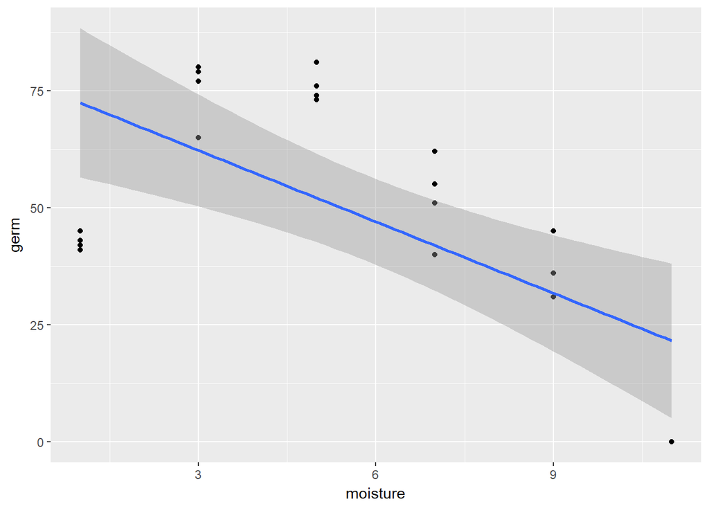

```r
data(seeds)

cov <- subset(seeds, seeds[,3]== "yes")
uncov <- subset(seeds, seeds[,3]== "no")

par(mfrow=c(1,2))
ggplot(cov, aes(x=moisture, y=germ)) +
  geom_point()+
  geom_smooth(method=lm)
```

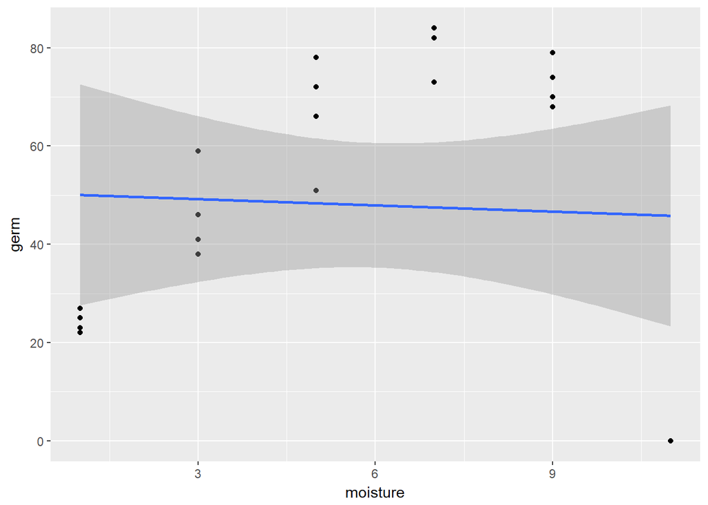

```r
ggplot(uncov, aes(x=moisture, y=germ)) +
  geom_point()+
  geom_smooth(method=lm)
```

From the plots we see that for covered boxes, germination percentage tend to decreases as the moisture level increase while it does not change much for uncovered boxes. This is an unexpected result and might be due to germination percentages for moisture level 11 for each box is being zero.

When we create a new factor describing the box and ddd lines to the previous plot that connect observations from the same box, plots are as below:

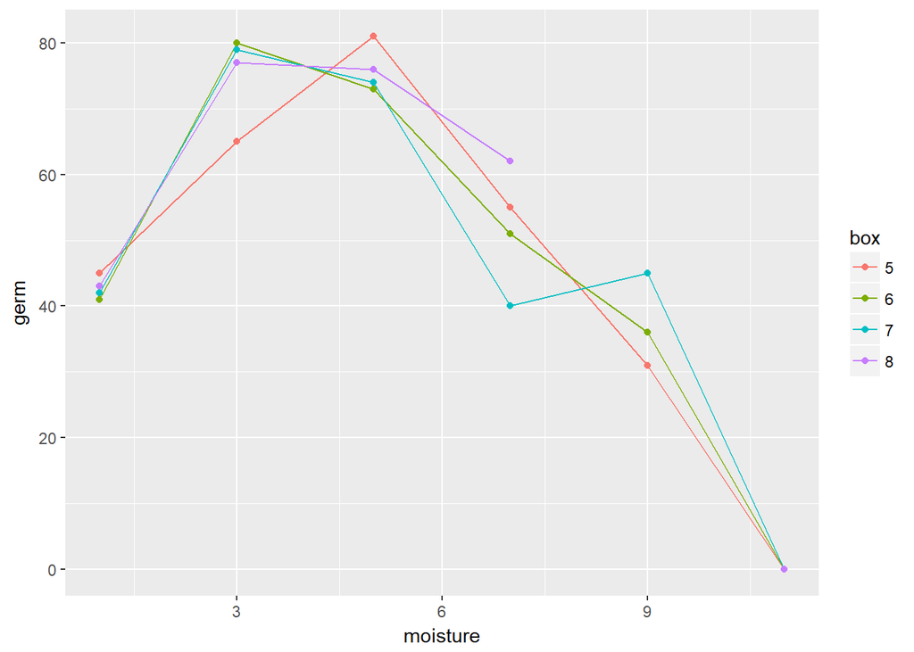

```r
seeds <- mutate(seeds, box = 1:nrow(seeds))
seeds$box <- factor(floor((seeds$box-1)/6 )+1)

cov <- subset(seeds, seeds[,3]== "yes")
uncov <- subset(seeds, seeds[,3]== "no")

par(mfrow=c(1,2))
ggplot(data=cov, aes(x=moisture, y=germ, line=box, group=box, color = box)) +
  geom_line()+
  geom_point()
```

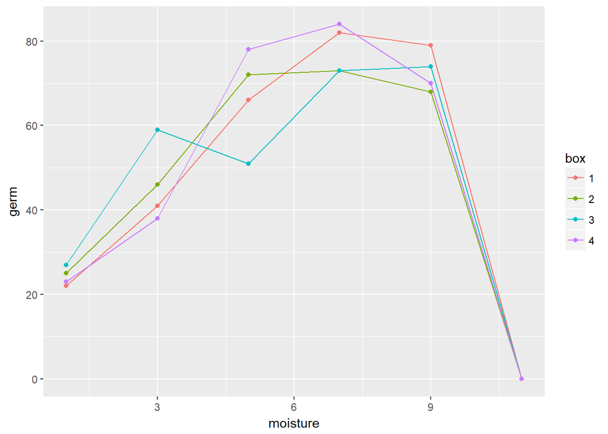

```r
ggplot(data=uncov, aes(x=moisture, y=germ, line=box, group=box, color = box)) +
  geom_line()+
  geom_point()
```

It seems like, there is not much of a box effect. Also, moisture level 11 seems to have some problems, i.e. it is equal to 0 for each box which is unexpected. Probably, value for level 11 is missing so we shall remove them and continue to the analysis with updated data.

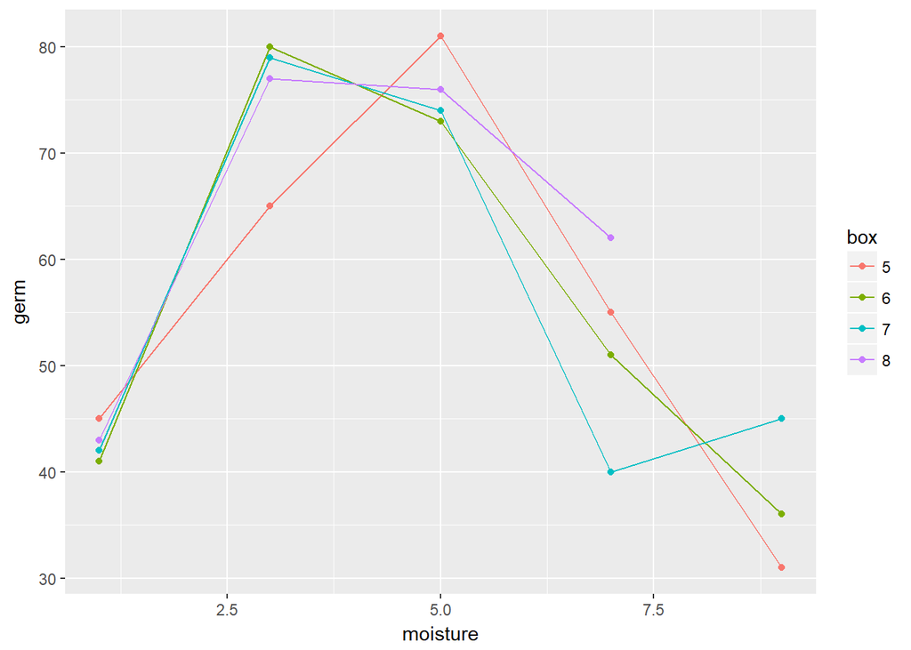

```r
seeds_update <- subset(seeds, moisture!= 11)

cov <- subset(seeds_update, seeds_update[,3]== "yes")
uncov <- subset(seeds_update, seeds_update[,3]== "no")

par(mfrow=c(1,2))
ggplot(data=cov, aes(x=moisture, y=germ, line=box, group=box, color = box)) +
  geom_line()+
  geom_point()
```

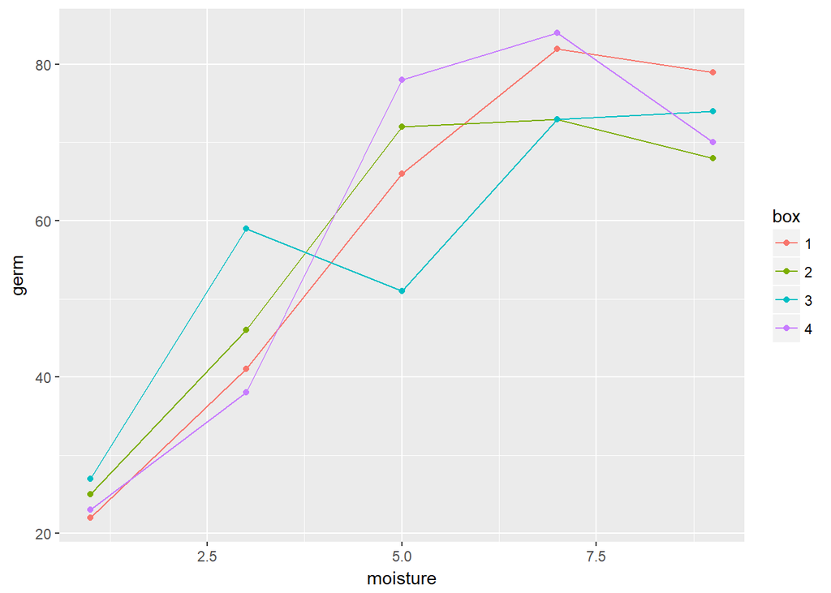

```r
ggplot(data=uncov, aes(x=moisture, y=germ, line=box, group=box, color = box)) +
  geom_line()+
  geom_point()
```

Now, we shall fit a binomial response model including the coverage, box and moisture predictors.

```r
total = 100
# blmod <- glm(cbind(germ,total-germ) ~ moisture + covered + box,
#              family=binomial, seeds)

blmod <- glm(cbind(germ,total-germ) ~ moisture + covered + box,
             family=binomial, seeds_update)
blmod
```

```
##
## Call:  glm(formula = cbind(germ, total - germ) ~ moisture + covered +
##     box, family = binomial, data = seeds_update)
##
## Coefficients:
## (Intercept)     moisture   coveredyes         box2         box3
##    -0.27008      0.12042      0.39603     -0.05046     -0.05046
##        box4         box5         box6         box7         box8
##     0.02537     -0.50496     -0.47160     -0.47995           NA
##
## Degrees of Freedom: 38 Total (i.e. Null);  30 Residual
##   (1 observation deleted due to missingness)
## Null Deviance:       600.2
## Residual Deviance: 486.1     AIC: 693.9
```

To test for the significance of a box effect in the model, we will use ANOVA.

```r
anova(update(blmod, . ~ . - box), blmod, test="Chisq")
```

```
## Analysis of Deviance Table
##
## Model 1: cbind(germ, total - germ) ~ moisture + covered
## Model 2: cbind(germ, total - germ) ~ moisture + covered + box
##   Resid. Df Resid. Dev Df Deviance Pr(>Chi)
## 1        36     503.92
## 2        30     486.13  6   17.791 0.006775 **
## ---
## Signif. codes:  0 '***' 0.001 '**' 0.01 '*' 0.05 '.' 0.1 ' ' 1
```

From the results, we see that p-value is quite small so we can say that box effect has a significance.

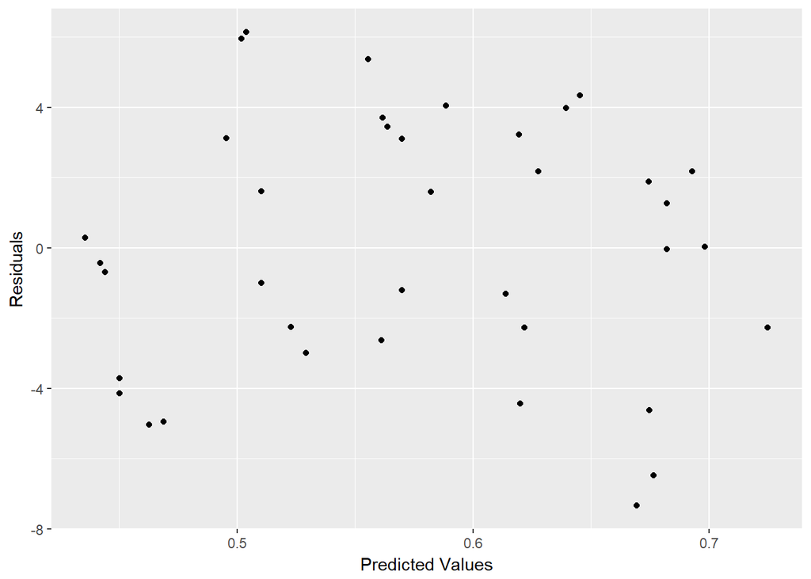

```r
ggplot()+
  geom_point(aes(x = predict(blmod, type="response"),y = residuals(blmod)))+
  xlab('Predicted Values') +
  ylab('Residuals')
```

Residuals seems to around zero, although their range is not small. They do not seem to have a particular shape.

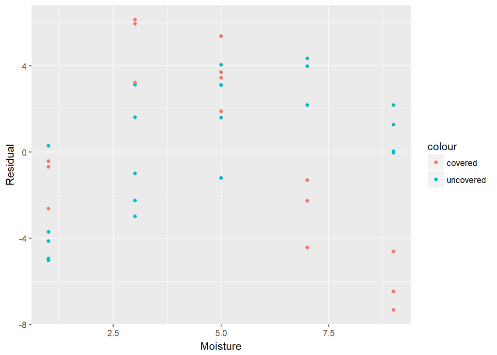

```r
ggplot()+
  geom_point(aes(x = seeds_update$moisture[1:23],y = residuals(blmod)[1:23], color = "uncovered"))+
  geom_point(aes(x = seeds_update$moisture[23:47],y = residuals(blmod)[23:47], color = "covered"))+
  xlab('Moisture') +
  ylab('Residual')
```

We see that for moisture level 1 and 3, residuals seems to be similar. For other moisture levels, they seem to be grouped which suggest that model cannot fit well both covered and uncovered values.

## Question 4

We are given “aflatoxin” data. It has dose, total and tumor columns.

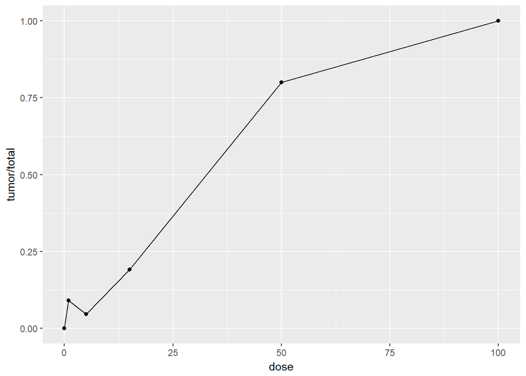

```r
data(aflatoxin)

ggplot(data=aflatoxin, aes(x=dose, y=tumor/total)) +
  geom_line()+
  geom_point()
```

From the plot of the proportion of animals with liver cancer against the dose, we see that as the dose increases, proportion of animals with liver cancer increases.

```r
blmod <- glm(cbind(tumor, total - tumor) ~ dose,
             family=binomial, aflatoxin)
blmod
```

```
##
## Call:  glm(formula = cbind(tumor, total - tumor) ~ dose, family = binomial,
##     data = aflatoxin)
##
## Coefficients:
## (Intercept)         dose
##    -3.03604      0.09009
##
## Degrees of Freedom: 5 Total (i.e. Null);  4 Residual
## Null Deviance:       116.5
## Residual Deviance: 2.897     AIC: 17.69
```

```r
summary(blmod)
```

```
##
## Call:
## glm(formula = cbind(tumor, total - tumor) ~ dose, family = binomial,
##     data = aflatoxin)
##
## Deviance Residuals:
##       1        2        3        4        5        6
## -1.2995   0.7959  -0.4814   0.4174  -0.1629   0.3774
##
## Coefficients:
##             Estimate Std. Error z value Pr(>|z|)
## (Intercept) -3.03604    0.48226  -6.295 3.07e-10 ***
## dose         0.09009    0.01456   6.189 6.04e-10 ***
## ---
## Signif. codes:  0 '***' 0.001 '**' 0.01 '*' 0.05 '.' 0.1 ' ' 1
##
## (Dispersion parameter for binomial family taken to be 1)
##
##     Null deviance: 116.524  on 5  degrees of freedom
## Residual deviance:   2.897  on 4  degrees of freedom
## AIC: 17.685
##
## Number of Fisher Scoring iterations: 5
```

When a model fitted the data, we see a quite low deviance and a low p-value for both intercept and coefficient indicating that model is likely to be a good fit.

```r
1-pchisq(116.524 - 2.897 ,1)
```

```
## [1] 0
```

```r
confint(blmod)
```

```
##                   2.5 %     97.5 %
## (Intercept) -4.10594724 -2.1868361
## dose         0.06440816  0.1217981
```

Predicted probability of liver cancer over the range of the data is shown in the graph below with blue line. Red line represent the data shown in (a).

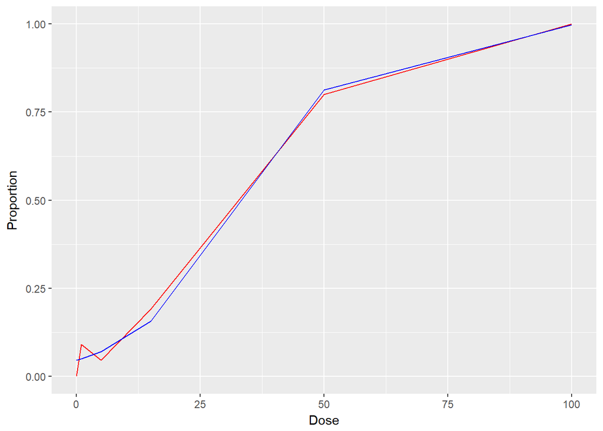

```r
d <- aflatoxin %>% mutate(pred = predict(blmod, type="response"))

ggplot() +
  geom_line(data = d, aes(x = dose, y = tumor/total), color = "red") +
  geom_line(data = d, aes(x =dose, y = pred), color = "blue") +
  geom_point() +
  xlab('Dose') +
  ylab('Proportion')
```

Now, we are to change to a probit link. We should compute the predicted probability under this model and add the curve to the existing plot. Newly predicted values are represented on the grap with green line.

```r
blmodprobit <- glm(cbind(tumor, total - tumor) ~ dose,
             family=binomial(link=probit), aflatoxin)
summary(blmodprobit)
```

```
##
## Call:
## glm(formula = cbind(tumor, total - tumor) ~ dose, family = binomial(link = probit),
##     data = aflatoxin)
##
## Deviance Residuals:
##        1         2         3         4         5         6
## -1.23164   0.89070  -0.47838   0.25563  -0.06575   0.12366
##
## Coefficients:
##              Estimate Std. Error z value Pr(>|z|)
## (Intercept) -1.736231   0.240449  -7.221 5.17e-13 ***
## dose         0.051933   0.007873   6.596 4.22e-11 ***
## ---
## Signif. codes:  0 '***' 0.001 '**' 0.01 '*' 0.05 '.' 0.1 ' ' 1
##
## (Dispersion parameter for binomial family taken to be 1)
##
##     Null deviance: 116.5243  on 5  degrees of freedom
## Residual deviance:   2.6241  on 4  degrees of freedom
## AIC: 17.413
##
## Number of Fisher Scoring iterations: 5
```

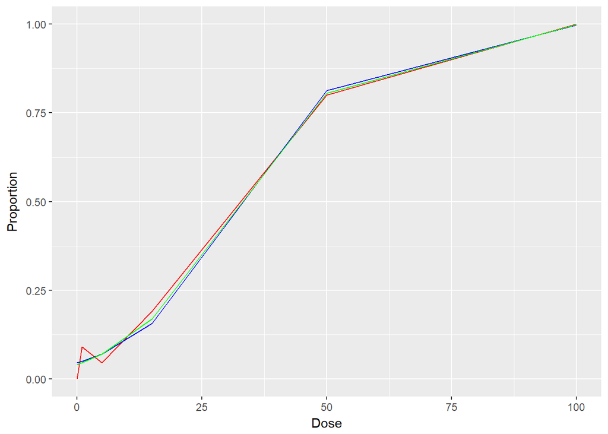

```r
d <- d %>% mutate(predprobit = predict(blmodprobit, type="response"))

ggplot() +
  geom_line(data = d, aes(x = dose, y = tumor/total), color = "red") +
  geom_line(data = d, aes(x =dose, y = pred), color = "blue") +
  geom_line(data = d, aes(x =dose, y = predprobit), color = "green") +
  geom_point() +
  xlab('Dose') +
  ylab('Proportion')
```

As can be seen from the graph, both methods predicts similar to real values except the first ones.

Now we shall compute the predicted probability of liver cancer for a dose of 25 ppb on the link scale and then compute a 95% confidence interval. Lastly, we should transform onto the probability scale. T do so, we should extract the coefficients of the model and multiply it with new data and then transform it using the ilogit function. Standard error and confidence interval are calculated similarly.

```r
blmodsum <- summary(blmod)
x0 <- c(1,25)
eta0 <- sum(x0*coef(blmod))
ilogit(eta0)
```

```
## [1] 0.3134978
```

```r
(cm <- blmodsum$cov.unscaled)
```

```
##              (Intercept)          dose
## (Intercept)  0.232574232 -0.0052817431
## dose        -0.005281743  0.0002118659
```

```r
se <- sqrt( t(x0) %*% cm %*% x0)
ilogit(c(eta0-1.96*se,eta0+1.96*se))
```

```
## [1] 0.1967999 0.4597827
```

To compute the predicted probability directly on the probability scale, we use predict function. It also returns standard error. We will use this standard error to construct a 95% confidence interval for the probability.

```r
predict(blmod,newdata=data.frame(dose=25),type = c("response"),se.fit = TRUE)
```

```
## $fit
##         1
## 0.3134978
##
## $se.fit
##          1
## 0.06836426
##
## $residual.scale
## [1] 1
```

```r
c(0.3134978-1.96*0.06836426 ,0.3134978+1.96*0.06836426)
```

```
## [1] 0.1795039 0.4474917
```

Second choice gives a slightly larger interval.

To compute the effective dose at 1%, 10% and at 50% levels with associated standard error, we will use dose.p function from MASS library.

```r
library(MASS)
dose.p(blmod,p=c(0.01,0.1,0.5))
```

```
##                 Dose       SE
## p = 0.01: -17.306078 7.681125
## p = 0.10:   9.310948 4.335968
## p = 0.50:  33.700496 3.800093
```

After calculation, we see that for 1% effective level of dose, prediction is negative and 95% of confidence interval also does not include a positive number or zero. We know that a level of dose cannot be zero, so this is probably caused by the model not being fit very well for the first couple of data point.